# Statistics for Psychologists 3.

**Computer lab 06**

**Course Number:** BTPS2040BA-E  
**Contact Information:** Please contact me through email anytime: abari.kalman@arts.unideb.hu

Author

Kálmán Abari

Published

March 28, 2025

Learning outcomes

Student will be familiar with file and directory handling.

**To earn 1 point**

To earn 1 point, submit all jamovi OMV files in this Computer lab that contain the activities you completed here. The subject of the email should be `Stat3 - Comp. lab 06`. Send the email to `abari.kurzus@gmail.com`.

# Worked Example 1

Previously, we discussed students’ aptitude towards sciences and humanities. In this example, we will examine whether school subjects differentiate into science and humanities based on students’ performance, or in other words, whether a two-factor model can be fitted to the data.

In Principal Component Analysis (PCA), our goal is primarily to reduce data complexity by creating new summary variables (principal components) that capture as much variance as possible from the original variables. PCA doesn’t distinguish between shared (common) variance and unique variance—it summarizes all variance together.

However, **Exploratory Factor Analysis (EFA)**—the approach we’re using here—is conceptually different. In EFA, we’re specifically interested in uncovering latent dimensions (factors) that explain the **shared variance** among the observed variables. In other words, EFA attempts to identify underlying constructs (e.g., aptitude for sciences and humanities) that explain why certain variables correlate with each other.

Thus, the key difference in this example is that, unlike PCA, we are explicitly testing whether the school subjects cluster meaningfully into two distinct latent constructs (science versus humanities). We are not just summarizing overall variance, but rather, looking to confirm theoretically meaningful latent variables (factors) within our data.

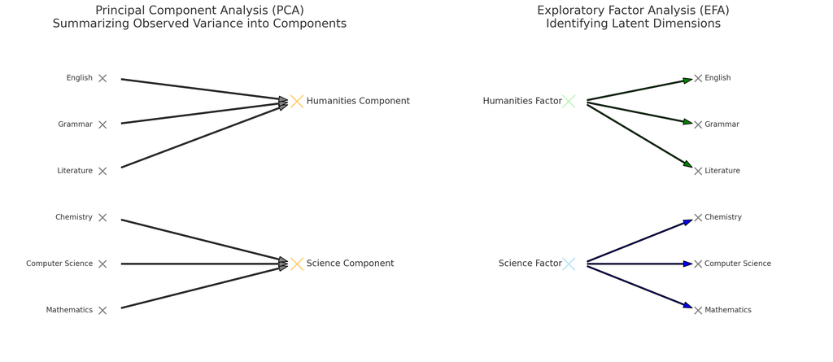

Diagrams above clearly highlighting the difference between PCA and EFA approaches:

## Step 1. Import database

Open the `efa_subjects.xlsx` file in jamovi.

[figure not shown]

## Step 2. Measure type

Set the measurement level of the variables. All variables are continuous, so we set the measurement level to `Continuous`.

[figure not shown]

## Step 3. Exploratory Factor Analysis

Perform an EFA on the dataset. Select **Analyses → Factor → Exploratory Factor Analysis**.

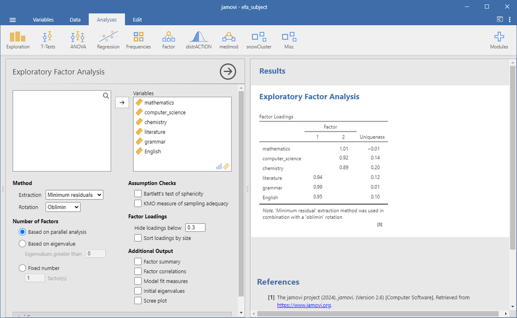

1. Move the variables to the `Variables` box: `mathematics`, `computer_science`, `chemistry`, `literature`, `grammar`, `English`.

2.Default settings are fine for now:

- Chose **Minimum residuals** as the extraction method.
- Selected **Oblimin rotation**, allowing factors to correlate.
- Set the number of factors based on **parallel analysis**, which determines how many latent factors adequately represent the observed data.
3. What Do We See in the Results?

**Uniqueness values** indicate how much variance each subject has that cannot be explained by the extracted factors. Here, low uniqueness (close to 0.10-0.20) means most variance is effectively explained by the factors.

Interpretation:

Thus, these results confirm our hypothesis that student performance data naturally separates into science and humanities dimensions.

## Step 4. Factor summary

To see the Factor summary table, click on the `Factor summary` box.

[figure not shown]

**“Factor Statistics – Summary”** in Jamovi provides crucial information about how effectively the extracted factors explain the variability present in the observed variables.

It consists of three columns:

**% of Variance**:

- This percentage expresses the proportion of total variance in all original variables explained by each factor individually.
- **Factor 1** explains **46.27%**, and **Factor 2** explains **44.38%** of the total variance.
- Each factor thus accounts for roughly equal amounts of variance, indicating balanced latent constructs.

**Cumulative %**:

- This column presents the total percentage of variance explained by all extracted factors combined.
- Here, two factors together explain **90.65%** of the variance in students’ performance scores across subjects.
- This very high cumulative percentage confirms that the two-factor model (Science vs. Humanities) fits the data very well, as it leaves relatively little variance unexplained.

**Overall Interpretation**:

- The **Factor Summary** clearly indicates that two latent dimensions are sufficient to capture most of the meaningful variance (over 90%) in the original set of subjects.
- Both factors (Science and Humanities) are roughly equally important in describing the structure of students’ academic performance.

This confirms the theoretical expectation that students’ performance naturally differentiates into these two broad latent constructs.

## Step 5. Assumption check

The common assumption in EFA is Bartlett’s test of sphericity, which tests whether the correlation matrix is significantly different from an identity matrix. The null hypothesis is that the correlation matrix is an identity matrix, meaning that the variables are uncorrelated. The second assumption is the Kaiser-Meyer-Olkin (KMO) measure of sampling adequacy, which tests whether the data are suitable for factor analysis.

To check this, click on the boxes in the `Assumption checks` section.

[figure not shown]

*Bartlett’s Test of Sphericity**

This statistical test checks if the correlation matrix among your variables is significantly different from an identity matrix (where all correlations would be zero).

- **χ² (Chi-square) = 222.56**, **df = 15**, **p < .0001**

Interpretation:

- The significant result (**p < .0001**) indicates that the correlation matrix is not an identity matrix. This means there **are meaningful correlations** between the variables (subjects).
- Therefore, the data is suitable for factor analysis.

If Bartlett’s test is not significant (p > .05), it would indicate that the variables are not sufficiently correlated, and factor analysis wouldn’t be appropriate.

*KMO Measure of Sampling Adequacy (MSA)**

The Kaiser–Meyer–Olkin (KMO) measure assesses how suitable your data is for factor analysis by examining the proportion of variance among variables that might be explained by underlying factors.

- **Overall KMO = 0.6784**

General rule of thumb for interpretation:

- **0.90–1.00**: Excellent
- **0.80–0.89**: Very good
- **0.70–0.79**: Good
- **0.60–0.69**: Mediocre (acceptable)
- **0.50–0.59**: Marginal (barely acceptable)
- **Below 0.50**: Unacceptable

Interpretation of your overall KMO (**0.6784**):

- This overall value indicates a mediocre-to-good suitability of the dataset for factor analysis, meaning your data is acceptable for the chosen analysis.

You also have individual KMO values for each variable, showing their adequacy for inclusion:

| Variable | KMO MSA | Adequacy Interpretation |
| --- | --- | --- |
| Mathematics | 0.5687 | Marginally acceptable |
| Computer Science | 0.6520 | Mediocre |
| Chemistry | 0.7055 | Good |
| Literature | 0.7304 | Good |
| Grammar | 0.6769 | Mediocre |
| English | 0.7788 | Good |

- Individual variables mostly range from marginally acceptable to good adequacy, reinforcing that your data overall supports the use of factor analysis.

**Overall Conclusion of Assumption Checks**

Based on these two tests:

- **Bartlett’s Test** indicates that the variables are significantly correlated, justifying the factor analysis.
- **Overall KMO** confirms that the dataset is suitable (mediocre-to-good adequacy).

Thus, the assumption checks clearly suggest your dataset meets the key assumptions for conducting and interpreting EFA meaningfully.

## Step 6. Factor correlation

To see the Factor correlation matrix, click on the `Factor correlation` box.

[figure not shown]

Here’s a detailed explanation of the **Inter-Factor Correlations** of your Jamovi Exploratory Factor Analysis (EFA) results:

In EFA, especially when using an **Oblimin rotation** (as in your example), we assume that the extracted factors might be correlated. The **Inter-Factor Correlation Matrix** shown here quantifies the correlation between your factors.

**What does a correlation of -0.2246 mean?**

- This negative correlation (**r = -0.2246**) indicates a **weak negative relationship** between the two factors.
- A negative correlation implies that students who score higher in **Science** subjects tend to score somewhat lower in **Humanities**, and vice versa—though this relationship is relatively mild.

Interpretation of correlation strength:

- **0.1–0.3**: Weak correlation
- **0.3–0.5**: Moderate correlation
- **Above 0.5**: Strong correlation

Thus, the observed correlation (-0.2246) is weak but noteworthy, suggesting that these two academic domains (science and humanities) are somewhat inversely related in students’ abilities or performance.

**Why is this useful?**

- The presence of even a small correlation justifies the choice of an oblique rotation (e.g., Oblimin), which allows factors to correlate.
- This makes the interpretation more realistic, as cognitive abilities or skills (science vs. humanities) are typically expected to have some relationship rather than being strictly independent.

**Conclusion**

The **Inter-Factor Correlations** confirm that:

- The two-factor solution (Science and Humanities) indeed captures two related yet somewhat distinct latent constructs.
- Choosing Oblimin rotation was appropriate, as factors show some meaningful correlation.

This enhances your theoretical interpretation: the identified latent constructs reflect two related yet distinct domains of academic abilities.

# Worked Example 2

Risk-taking is a behavior characteristic of a person that appears in situations with uncertain outcomes. It is important to add that individuals often voluntarily choose to participate in such situations. But what kinds of risks exist? Numerous varieties are known. Risk is taken by someone gambling in a casino, speculating on the stock market, or trying their luck at cards, as well as someone who parachutes from an airplane or races around a track at speeds exceeding 300 km/h. As the examples demonstrate, we can classify types of risk-taking according to the factors involved. In one category, people risk their **physical safety** (as in auto racing), while in others, they risk money or something related to **reputation or honor** (such as bluffing in card games). In our final example, we will examine whether factor analysis supports our assumption, that is, whether risk-taking can be classified into two distinct types: **physical risk-taking** and **financial risk-taking**.

The data in the database were obtained by asking participants to rate how likable they found individuals from various occupations or those engaged in different activities. Ratings were given on a 1–5 scale, where a score of 5 indicated the person was very likable. In this way, we obtained a measure of participants’ attitudes toward risk. The variables include individuals such as card players, racecar drivers, businessmen (who risk large amounts of money), extreme sports participants, people placing large bets, bluffers, and professional soldiers.

## Step 1. Import database

Open the `efa_risk.xlsx` file in jamovi.

Our database contains the ratings of individuals from various occupations or activities: card players, racecar drivers, businessmen, extreme sports participants, people placing large bets, bluffers, and professional soldiers.

[figure not shown]

## Step 2. Measure type

Set the measurement level of the variables. All variables are continuous, so we set the measurement level to `Continuous`.

[figure not shown]

## Step 3. Exploratory Factor Analysis

Perform an EFA on the dataset. Select **Analyses → Factor → Exploratory Factor Analysis**. Move the variables to the `Variables` box: `card`, `racecar_driver`, `businessman`, `extreme_sport`, `betting`, `bluff`, `soldier`. Check Scree plot under Additional options.

[figure not shown]

[figure not shown]

We performed an **Exploratory Factor Analysis (EFA)** using the following settings:

- Extraction method: **Minimum residuals**
- Rotation method: **Oblimin** (allows factors to correlate)
- Number of factors: Determined by **parallel analysis** (Jamovi compares your data to simulated random data to decide the appropriate number of factors).
- Variables included were:  
  **card, racecar_driver, businessman, extreme_sport, betting, bluff, soldier**
- Additional options:  
  **Scree plot** checked to visually assess the number of factors.

**Why did Parallel Analysis yield different factor solutions (2 vs. 3 factors)?**

If you run the parallel analysis multiple times (remove, then re-add variables), you may notice that it sometimes suggests a two-factor solution, while other times it suggests a three-factor solution. This can happen due to the following reasons:

- **Parallel analysis** is based on comparing your data’s eigenvalues against randomly generated (simulated) eigenvalues. Because of its reliance on randomness, parallel analysis can sometimes yield slightly different solutions when performed multiple times.

This usually happens when:

- The eigenvalue of an additional factor (e.g., the third factor) is very close to the eigenvalues generated by random simulations. **You can see this in the scree plot, where the third eigenvalue is close to the simulated values**.
- Sample sizes are relatively small or the data structure is borderline, making the factor structure less clear-cut.

**What should you do in such cases?**

To make a well-informed decision, consider the following strategies:

**Check Stability through Multiple Runs**

- Repeat the parallel analysis several times.
- If the same number of factors consistently emerges (e.g., two factors in most analyses), choose the most stable solution.

**Consider Theoretical and Interpretational Clarity**

- Evaluate whether the additional factor (e.g., the third factor) makes sense theoretically and practically.
- If the extra factor is difficult to interpret or does not provide additional theoretical insight, prefer the simpler (two-factor) solution.

**Examine Goodness-of-Fit Measures**

- Compare fit indices or residual variances for both two- and three-factor solutions.
- If a three-factor solution provides significantly better model fit or explains considerably more variance, it may justify choosing three factors. If the difference is minor, stick to the simpler solution.

**Validate with Alternative Extraction Methods**

- Consider using other extraction methods (e.g., Principal Axis Factoring, Maximum Likelihood).
- If alternative methods consistently suggest one solution (e.g., two factors), this provides additional support for that choice.

**Summary of Recommended Approach**

When parallel analysis produces borderline or inconsistent results:

- Run the parallel analysis multiple times to test stability.
- Focus on interpretability and theoretical consistency.
- Check model-fit indicators for both solutions.
- Validate your findings using different extraction methods.

Ultimately, choose the number of factors that is stable, interpretable, theoretically meaningful, and provides good model fit.

### Interpretatiion of result of EFA with 3 factors:

**Factor 1: Financial/Gambling Risk**

- **card** (loading: 1.0070, unusually high and strongly representative of this factor)
- **betting** (loading: 0.5041)

This factor clearly relates to risk-taking behaviors involving money and gambling.

**Factor 2: Physical Risk**

- **racecar_driver** (loading: 0.5098)
- **extreme_sport** (loading: 0.4432)
- **soldier** (loading: 0.4257)

This factor represents activities that pose risks primarily to physical safety and involve direct physical danger.

**Factor 3: Social/Financial Risk**

- **bluff** (loading: 0.5446; strongly associated with reputational or social risk)
- **businessman** (loading: 0.3962; primarily financial or investment-related risk)

This factor emphasizes behaviors that risk reputation or social standing, combined with financial uncertainty.

**Notes on Uniqueness:**

- **Uniqueness** shows the variance in each variable not explained by these three factors.
- The negative uniqueness value (**card: -0.0129**) is unusual, possibly due to estimation anomalies or extremely high correlations with other variables.

**Eigenvalues and Scree Plot (bottom-right)**

The **Scree Plot** displays eigenvalues, indicating how much variance each factor explains:

- **Blue line (“Data”):** Actual eigenvalues from your data.
- **Orange line (“Simulations”):** Randomly generated baseline eigenvalues.

Interpretation:

- **Factor 1** clearly exceeds simulated data values, strongly supporting its validity.
- **Factor 2** moderately surpasses the simulated data line, clearly indicating it is also meaningful.
- **Factor 3** is very close to simulated values, making it borderline meaningful.
- Additional factors fall below the simulated data line, indicating no further meaningful dimensions.

Thus, the Scree Plot supports clearly two factors, with a borderline third factor, justifying either a two- or three-factor model depending on theoretical clarity.

**Overall Conclusion**

Your EFA results identify:

- **Factor 1: Financial/Gambling Risk**
- **Factor 2: Physical Risk** *(correctly including racecar_driver)*
- **Factor 3: Social/Financial Risk** *(borderline, but meaningful if theoretically justified)*

Given that the third factor (Social/Financial Risk) is borderline, it may be helpful to examine this further in terms of theoretical expectations, interpretability, and possibly additional analyses to finalize the decision about factor retention.

### Interpretation of result of EFA with 2 factors:

This table shows how strongly each observed variable relates (loads) onto two identified latent factors. Loadings indicate correlations between observed variables and underlying latent factors:

Interpretation of Factors:

- **Factor 1 (Financial/Social Risk)** primarily includes variables related to gambling and financial or social stakes:
  - Card playing (**0.8964**, very strong loading)
  - Betting (**0.5710**)
  - Businessman (**0.3613**, moderate loading, reflecting financial risk)
  - Bluffing (**0.3545**, also associated with social or reputational risk)
- **Factor 2 (Physical Risk)** mainly represents variables involving physical danger or personal safety:
  - Extreme sports (**0.5126**, strong loading)
  - Racecar driving (**0.4559**, moderate loading)
  - Soldier (**0.3789**, moderate loading, reflects physical and occupational risks)

Uniqueness:

- Represents the proportion of variance in each variable not explained by the two factors.
- Variables with lower uniqueness (e.g., card: 0.1942) are better explained by factors, while higher uniqueness values (e.g., bluff: 0.8646) suggest significant variance remains unexplained by these two factors.

**Eigenvalues and Scree Plot (lower-right)**

The Scree Plot illustrates eigenvalues, representing how much total variance each extracted factor explains in the data:

- **Blue line (Data)**: eigenvalues calculated from your real dataset.
- **Orange line (Simulations)**: eigenvalues from randomly generated simulated data.

Factors whose eigenvalues from actual data exceed those from simulations suggest meaningful underlying dimensions.

- Factor 1 and Factor 2 eigenvalues from your data clearly exceed the simulation data, indicating these two factors effectively represent meaningful latent structures.
- Factor 3 and onward closely follow or fall below the simulation line, confirming that additional factors would not substantially improve understanding or representation of data structure.

Thus, the Scree Plot clearly justifies choosing a **two-factor solution**.

**Overall Interpretation and Conclusion**

This analysis identifies two distinct and meaningful latent dimensions of attitudes toward risk-taking behaviors:

1. **Factor 1 (Financial and Social Risk)**:
   - Associated primarily with gambling, financial risk, and some aspects of reputational/social risk.
2. **Factor 2 (Physical Risk)**:
   - Associated with personal safety, physical danger, and occupational hazards.

The results of parallel analysis (visualized through the Scree Plot) strongly support retaining two factors, providing clear empirical evidence that attitudes toward risk-taking behaviors group naturally into these two distinct underlying categories.

### Assumption Checks and Factor Correlation with 3 factors

To see the Assumption checks and Factor correlation matrix, click on the boxes in the `Assumption checks` and `Factor correlation` sections.

[figure not shown]

[figure not shown]

**First Image: Assumption Checks**

This image includes two important statistical checks to determine if Exploratory Factor Analysis (EFA) is appropriate for your data:

- **Bartlett’s Test of Sphericity:**
  - A significant Bartlett’s test (p < .0001) means the variables in your data are sufficiently correlated. This indicates that your dataset is suitable for conducting factor analysis.
  - **KMO Measure of Sampling Adequacy**
    - **Overall KMO (0.5767)** is marginally acceptable (0.50–0.59), suggesting caution in interpretation.
    - Variables **bluff (0.7469)** and **businessman (0.7035)** indicate good sampling adequacy.
    - However, **racecar_driver (0.4510)** is below the acceptable threshold (0.50), which indicates it may not be suitable or may not fit neatly into the extracted factors.

In summary, the assumption checks show your data is acceptable but somewhat limited in terms of sampling adequacy. Consider either removing variables with low KMO values (e.g., racecar_driver) or obtaining more data to improve the factor solution quality.

*Second Image: Factor Statistics (Three-Factor Solution)**

This image provides detailed statistics on your three-factor solution.

**Factor Summary**

Interpretation:

- Factor 1 captures **19.79%** of the variance, clearly representing the primary dimension of risk-related attitudes (e.g., financial/gambling risk).
- Factor 2 captures an additional **9.38%**, and
- Factor 3 another **8.79%**, indicating additional meaningful yet smaller contributions to the variance.
- Altogether, the three-factor solution explains about **38% of total variance**, indicating a moderately informative factor structure.

**Inter-Factor Correlations:**

**Interpretation:**

- Factors 1 and 3 have a moderate positive correlation (**0.4390**), suggesting some conceptual overlap (e.g., financial/social risk behaviors might be somewhat related).
- Factors 1 and 2 (**0.0260**) and factors 2 and 3 (**0.0985**) have very weak correlations, indicating that the second factor (likely physical risk) is largely independent of the others.

*Overall Interpretation and Recommendations:**

- **Suitability Checks:**  
  Your data is suitable but somewhat limited due to marginal sampling adequacy. Improve by removing problematic variables or collecting more data.

**Factor Structure:**  
The three-factor solution meaningfully explains your data. The factors could be interpreted as: - **Factor 1:** Financial/Gambling risks (dominant factor). - **Factor 2:** Physical risks (clearly distinct factor). - **Factor 3:** Social/Financial risks (related but distinct).

- **Factor Correlations:**  
  Factor 1 and 3 share moderate overlap; Factor 2 stands separately, suggesting conceptually distinct risk dimensions.

Consider validating these findings further through additional analysis or theoretical interpretation, especially given the borderline adequacy of some assumptions.

### Assumption Checks and Factor Correlation with 2 factors

To see the Assumption checks and Factor correlation matrix, click on the boxes in the `Assumption checks` and `Factor correlation` sections.

[figure not shown]

[figure not shown]

**Factor Statistics - Summary:**

This table summarizes how much variance each factor explains

**Interpretation:**

- **Factor 1** explains **21.25%** of total variance. This indicates that the first latent factor captures a substantial portion of the variance in how people rate individuals involved in risky behaviors.
- **Factor 2** explains an additional **9.40%**, contributing to a cumulative **30.65%** variance explained by the two-factor model. Although this isn’t very high, it still provides meaningful additional explanatory power.

**Inter-Factor Correlations:**

This table shows correlations between the factors.

**Interpretation:**

**Second Image: Assumption Checks**

- **Bartlett’s Test of Sphericity:**
  - A highly significant result (**p < .0001**) means that your correlation matrix significantly differs from an identity matrix (no correlations). This confirms that meaningful correlations exist among variables, making factor analysis appropriate.

**KMO Measure of Sampling Adequacy:**

The KMO (Kaiser–Meyer–Olkin) measures if your variables are suitable for factor analysis.

**Interpretation of overall KMO (0.5767):**

- The value is considered marginal (barely acceptable):
  - **≥ 0.80**: Excellent
  - **0.70-0.79**: Good
  - **0.60-0.69**: Mediocre
  - **0.50-0.59**: Marginal (barely acceptable)
  - **< 0.50**: Not acceptable

Your overall KMO (0.5767) is acceptable but marginally low, suggesting that the dataset could be improved (e.g., increasing sample size or reviewing variables).

**Individual KMO values:**

- Variables like **bluff (0.7469)** and **businessman (0.7035)** have good KMO scores.
- Variables such as **racecar_driver (0.4510)** fall below the acceptable threshold (0.50), indicating they may not fit particularly well into the factor structure and could be reconsidered or excluded.

*Overall Conclusion:**

- **Factor Summary** indicates two factors meaningfully summarize your data, although total explained variance is moderate (~31%).
- **Inter-factor correlations** suggest independence between the two factors.
- **Bartlett’s test** confirms factor analysis suitability due to sufficient correlations among variables.
- **KMO test** indicates marginal overall suitability, suggesting caution. Consider revising the variable set or collecting additional data.

Thus, your results justify conducting factor analysis but suggest some improvement opportunities in the dataset or selected variables for future analyses.

### Our decision

Given the borderline adequacy of the three-factor solution and the clearer interpretability of the two-factor model, we recommend proceeding with the two-factor solution. This model provides a more straightforward and conceptually clear representation of risk-taking attitudes, with a more robust factor structure and clearer interpretability.

To set the number of factors, we considered:

- **Theoretical Interpretability:** Two factors (Financial/Social Risk and Physical Risk) are conceptually clear and distinct, aligning well with our expectations.
- **Statistical Support:** The two-factor solution explains a substantial portion of variance (30.65%) and shows very weak inter-factor correlations, indicating distinct constructs.
- **Practical Implications:** A two-factor model is more parsimonious and easier to interpret, making it more useful for practical applications and theoretical discussions.

Based on these considerations, we recommend proceeding with the two-factor solution for further analysis and interpretation.

[figure not shown]

# Worked Example 3

There is a familiar, though not particularly pleasant feeling: anxiety. Everyone has experienced it at some point, although the intensity and circumstances vary widely. Anxiety can arise from many causes—a challenging exam, an operation, an important job interview, and so forth. Sometimes people have “rational” reasons to feel anxious; for example, when facing an important job interview that could influence the next twenty years of their lives, most people experience some degree of tension or anxiety. However, there are individuals who worry about something almost constantly and feel continuous anxiety. To others, this anxiety often seems irrational, since no external circumstances appear to justify the worry (a typical example would be mothers who constantly worry about their children). For such individuals, anxiety becomes a defining aspect of their personality—a personality trait.

In our dataset, we find (hypothetical) data referring to **state and trait anxiety**. The first three items relate to **state anxiety**, while the remaining three items target **trait anxiety**. The survey included the following questions:

- **v1**: I feel restless.
- **v2**: I am worried.
- **v3**: I am afraid that something bad will happen.
- **v4**: I tend to take everything to heart.
- **v5**: I feel like my life is full of difficulties.
- **v6**: I couldn’t imagine a life easier than mine.

The first three items target **state anxiety**, while the remaining three focus on **trait anxiety**.

- **v1–v3**: state anxiety
- **v4–v6**: trait anxiety

Both our intuition and the psychological literature suggest that anxiety can be divided into two components or two **factors**. The relationship between these two factors is illustrated in the diagram below.

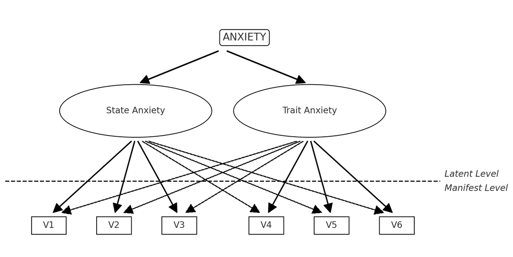

The figure shows that the two components (factors) of anxiety cannot be observed or measured directly. However, with the help of the related items, they can become manifest and measurable. All items (variables) are connected to both factors: **items v1–v3** are more strongly related to **state anxiety**, while **items v4–v6** are more strongly related to **trait anxiety**.

**Factor analysis** provides an excellent tool for determining the strength of these relationships, thereby offering statistical support for the underlying **theoretical latent structure**.

## Step 1. Import database

Open the `efa_anxiety.xlsx` file in jamovi.

Our database contains the ratings of individuals on state and trait anxiety. The first three items relate to state anxiety, while the remaining three items target trait anxiety: `v1`, `v2`, `v3`, `v4`, `v5`, `v6`.

[figure not shown]

## Step 2. Measure type

Set the measurement level of the variables. All variables are continuous, so we set the measurement level to `Continuous`.

[figure not shown]

## Step 3. Exploratory Factor Analysis

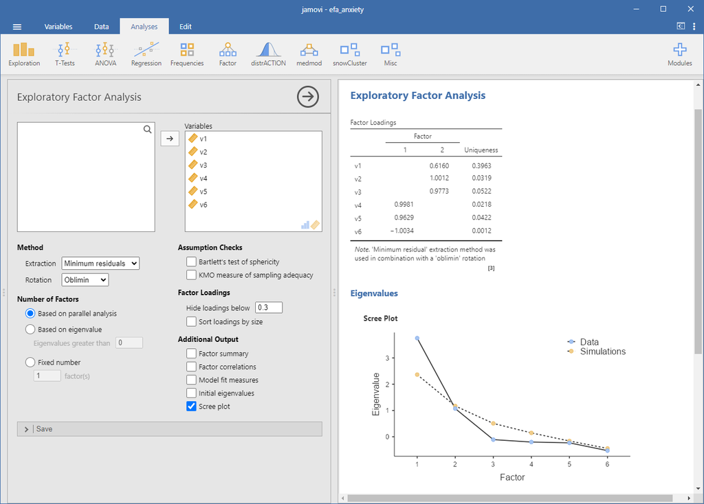

Method and Rotation in jamovi

- **Estimation Method: Minimum Residuals**  
  This method estimates factors by minimizing the difference between the observed correlation matrix and the model’s predicted correlations.
- **Rotation: Oblimin (Oblique)**  
  Since state and trait anxiety are often correlated in real life, using an oblique rotation (Oblimin) makes sense: it allows the two factors to correlate with each other, reflecting the fact that people who experience high state anxiety might also tend to have high trait anxiety (and vice versa).

Number of Factors

- **Theoretical expectations** (state vs. trait anxiety).
- **Empirical indicators**: parallel analysis suggests a 2-factor solution.

Factor Loadings

- Each variable (v1–v6) shows a **loading** on either Factor 1 or Factor 2.
- A higher loading (closer to 1 in absolute value) indicates that the item is strongly associated with that factor.
- For example, if items v1, v2, and v3 load highly on Factor 1, we interpret that factor as **state anxiety**. If v4, v5, and v6 load on Factor 2, we interpret that factor as **trait anxiety**.

Uniqueness

- The **Uniqueness** value for each variable indicates how much of that variable’s variance is **not** explained by the two factors.
- Lower uniqueness means the factor solution accounts for more of that item’s variance—i.e., the item is well-explained by the factor model.

Eigenvalues and Scree Plot

- The **Scree Plot** in the output shows a clear drop after the second factor, supporting a 2-factor solution.
- Factors 1 and 2 each have eigenvalues above 1, while subsequent factors have much smaller eigenvalues.

Interpreting the Factors

- Based on the theoretical background and the item content, **Factor 1** could be labeled “State Anxiety” and **Factor 2** “Trait Anxiety” (or vice versa, depending on which factor the items load onto).
- Because you used **Oblimin** rotation, you can check the **factor correlation** to see how much these two anxiety components overlap. In many studies, state and trait anxiety are moderately correlated—people with a tendency toward trait anxiety are more prone to experience state anxiety in various situations.

Bringing It All Together

- **State Anxiety (v1–v3)**: Reflects momentary, situation-specific worry or fear (e.g., feeling restless, worried about something bad happening).
- **Trait Anxiety (v4–v6)**: Reflects a more enduring predisposition to worry, even when there is no immediate cause (e.g., taking everything to heart, perceiving life as difficult).

Your EFA confirms that these **two distinct but related factors** exist in the data. This finding is consistent with well-established psychological theories that differentiate between **short-term (state)** and **long-term (trait)** aspects of anxiety.

Key Takeaways

1. **Two-Factor Structure**: The analysis supports the theoretical distinction between state and trait anxiety.
2. **Item Clustering**: Items v1–v3 cluster around state anxiety, while v4–v6 cluster around trait anxiety.
3. **Correlation of Factors**: An oblique rotation acknowledges that these factors are likely correlated in real-world settings.
4. **Practical Implications**: This helps researchers and clinicians understand that while some individuals may only feel anxiety in specific situations, others have a more generalized anxiety that permeates daily life.

This EFA thus provides both **theoretical and empirical** insight into how state and trait anxiety emerge as separate yet related constructs within the same dataset.

## Step 4. Factor summary and Factor correlation

[figure not shown]

**Factor Statistics**

This part of the output provides **summary information** about the extracted factors and the **correlation between them**.

**Factor Summary Table**

- Interpretation:
  - **SS Loadings (Sum of Squared Loadings)**: Represents the total amount of variance explained by each factor across all items.
  - Factor 1 explains the most variance (**≈3.06**), which suggests it is the **dominant dimension** in the data.
  - **% of Variance**:
    - **Factor 1** explains about **51.06%** of the total variance.
    - **Factor 2** explains an additional **39.85%**.
  - Together, these two factors explain **over 90%** of the total variance, which is **very high** and indicates that the two-factor model provides a strong fit to the data.
  - **Cumulative %**: This is simply the running total of explained variance by the extracted factors.
  - The two factors combined account for **90.91%** of the total variance, supporting the **validity of a two-factor structure** (e.g., possibly **State Anxiety** and **Trait Anxiety**).

**Inter-Factor Correlations**

- Interpretation:
  - This matrix shows the **correlation between the two extracted factors**.
  - The correlation value of **0.4205** between Factor 1 and Factor 2 indicates a **moderate positive relationship**.
  - This suggests that while the two factors are distinct, they are not completely independent—**individuals who score high on one may also tend to score high on the other**.

Overall Conclusion:

- The two-factor solution fits the data well, explaining a **very large proportion of variance (90.91%)**.
- The factors are **moderately correlated**, meaning they are related but measure different aspects of the underlying construct (in this case, likely **anxiety**).
- These results align well with psychological theory that distinguishes between **state and trait anxiety** as **related but separate constructs**.

This output provides strong statistical support for the two-dimensional structure of the questionnaire items.

## Step 5. Assumptions

[figure not shown]

This explanation focusing on the **Assumption Checks** in our jamovi EFA output—namely, **Bartlett’s test of sphericity** and the **KMO measure of sampling adequacy**. These tests help determine whether your dataset is suitable for factor analysis.

1. Bartlett’s Test of Sphericity
- **Purpose**: This test checks if the correlation matrix significantly differs from the identity matrix (where all correlations are zero).
- **Interpretation**:
  - A **significant** result (p < .05) indicates that there are enough correlations among your variables to justify factor analysis.
  - If this test were **not significant**, it would suggest that the variables do not correlate enough to form meaningful factors.

In the screenshot, if you see **p < .05**, it confirms that your data likely have sufficient intercorrelations for an EFA.

### 2. KMO (Kaiser–Meyer–Olkin) Measure of Sampling Adequacy

- **Purpose**: KMO assesses how well each variable in your dataset is predicted by the others via pairwise correlations. It gives you both an **overall** measure and individual KMO values for each variable (v1–v6).
- **Interpretation**:
  - **KMO > .80** is considered **“meritorious”** or “very good.”
  - **KMO between .70–.80** is “good.”
  - **KMO between .60–.70** is “mediocre” but still acceptable.
  - **KMO < .50** generally indicates that the data may not be well-suited for factor analysis (you might need to consider removing variables with very low individual KMO values or collecting more data).

Why These Tests Matter for Anxiety Research

Given your dataset focuses on **state** (v1–v3) and **trait** (v4–v6) anxiety, you want to be sure these items have enough intercorrelation to form distinct factors. The **significant Bartlett’s test** confirms that the items do correlate sufficiently, and the **KMO values** show that, overall, your data are suitable for extracting factors (though they may not be perfect). This helps validate the theoretical expectation that state and trait anxiety are related but distinguishable constructs, making EFA an appropriate method to explore their underlying factor structure.

Key Takeaways

1. **Bartlett’s Test** (p < .05) → There are sufficient correlations among items for factor analysis.
2. **KMO** (> .50 overall) → The data are acceptable for factor analysis, though higher values are preferred for stronger factor solutions.
3. **Individual KMO Values** → Check if any single variable has a particularly low KMO, which might indicate it does not fit well with the others.

These assumption checks give you confidence that proceeding with an EFA to distinguish between **state** and **trait** anxiety is methodologically sound.

# Worked Example 4

The researcher wanted to find out what benefits consumers look for when purchasing toothpaste. Using a sample of 30 participants, respondents were asked to indicate how much they agree with the following statements (1 = strongly disagree; 7 = strongly agree):

- **v1**: It is important for me to buy a toothpaste that can prevent tooth decay.
- **v2**: I like toothpastes that make my teeth shiny.
- **v3**: A toothpaste should strengthen the gums.
- **v4**: I like toothpastes that provide fresh breath.
- **v5**: Preventing tooth decay is not an important expectation for me.
- **v6**: The most important factor when purchasing toothpaste is having beautiful teeth.”

Our goal is to identify the underlying factors that drive consumer preferences for toothpaste. The researcher suspects that these preferences may be driven by two main factors: **oral health benefits** (e.g., preventing tooth decay, strengthening gums) and **cosmetic benefits** (e.g., shiny teeth, fresh breath, beautiful teeth). The EFA will help determine if these two factors indeed underlie consumer preferences for toothpaste.

## Step 1. Import database

Open the `efa_toothpaste.xlsx` file in jamovi.

Our database contains the ratings of individuals on various toothpaste preferences: `v1`, `v2`, `v3`, `v4`, `v5`, `v6`.

[figure not shown]

## Step 2. Measure type

Set the measurement level of the variables. All variables are continuous, so we set the measurement level to `Continuous`.

[figure not shown]

## Step 3. Exploratory Factor Analysis

[figure not shown]

The goal is to identify the main factors (dimensions) that drive consumer choices when buying toothpaste.

1. EFA Settings and Results:
- **Extraction Method**: *Minimum Residuals*  
  This method minimizes the squared differences (residuals) between the observed and model-predicted correlations.
- **Rotation**: *Oblimin (Oblique)*  
  An oblique rotation allows factors to correlate with each other. This is useful if you expect that different toothpaste benefits (e.g., health vs. cosmetic benefits) might be somewhat related in practice.
- **Number of Factors**: Based on the scree plot and eigenvalues, the software extracted two factors. This suggests that respondents primarily evaluate toothpaste benefits along two main dimensions.
2. Factor Loadings:

The table shows which items (v1–v6) load onto which factor, and how strongly. The following example outlines the logic (the exact loadings appear in your screenshot):

- **Factor 1**
  - *v1*: “It is important for me to buy a toothpaste that can prevent tooth decay.”
  - *v3*: “A toothpaste should strengthen the gums.”
  - *v5*: “Preventing tooth decay is not an important expectation for me.” (with a **negative** loading)

  Since v5 is phrased negatively (“Preventing tooth decay is not important”), a **negative loading** indicates that people who **disagree** with this statement (i.e., those who do consider prevention important) would effectively score **high** on this factor. Thus, Factor 1 reflects **“prevention/health protection.”**
- **Factor 2**
  - *v2*: “I like toothpastes that make my teeth shiny.”
  - *v4*: “I like toothpastes that provide fresh breath.”
  - *v6*: “The most important factor when buying toothpaste is having beautiful teeth.”

  These items focus on **cosmetic or aesthetic** aspects (shiny teeth, fresh breath, beauty). Hence, Factor 2 can be interpreted as **“beauty/comfort.”**
3. Interpreting the Two Factors:

Based on the item content and their loadings, we can label the two factors as follows:

1. **Factor 1 – “Health & Prevention”**
   - Main themes: preventing tooth decay, strengthening gums.
   - The negative loading of v5 indicates that people who consider prevention important score high on this dimension.
2. **Factor 2 – “Aesthetics & Freshness”**
   - Main themes: shiny teeth, fresh breath, emphasis on having attractive teeth.

These factors align with the researcher’s assumption that consumers might look for **health-related** (preventive) benefits and **cosmetic/comfort** benefits in toothpaste.

4. Scree Plot and Eigenvalues:

In the lower right area of the output, the **Scree Plot** shows a clear drop in eigenvalues after the second factor. This supports a **two-factor** solution, as factors beyond the second have eigenvalues well below 1.

5. Conclusions and Practical Implications:
- The analysis reveals **two main consumer motivations**:
  1. **Health & prevention** (decay prevention, gum protection),
  2. **Aesthetics & comfort** (shiny teeth, fresh breath, beauty).
- **Methodologically**, the Minimum Residuals approach with Oblimin rotation is appropriate here, given that the two factors may correlate (those who value health might also place some importance on aesthetics).
- From a **marketing or product development** standpoint, manufacturers should note that some consumers prioritize preventive health benefits (e.g., cavity prevention, gum strength), while others focus more on the toothpaste’s “cosmetic” properties (e.g., whitening, fresh breath).

Summary

The EFA results point to two distinct but potentially correlated dimensions in consumers’ toothpaste preferences: **health/prevention** and **aesthetics/comfort**. This confirms the dual nature of the survey items and highlights the most important considerations behind consumer choices when buying toothpaste.

## Step 4. Factor summary and Factor correlation

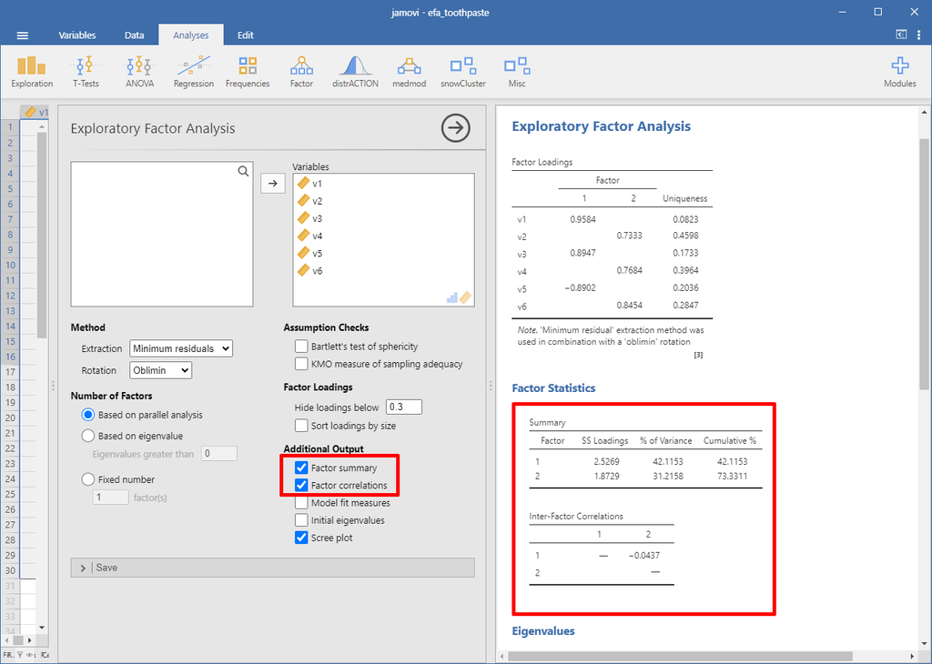

1. Factor Summary

The **Factor Summary** table provides insights into how well the extracted factors represent the variability in the original variables (v1–v6). It shows three key statistics for each factor:

- **SS Loadings (Sum of Squared Loadings)**:  
  This value represents how much variance in all variables is explained by each factor. Higher values indicate a factor explaining a substantial amount of variance.
- **% of Variance**:  
  It indicates the percentage of the total variance accounted for by each factor individually.
- **Cumulative %**:  
  This shows the total percentage of variance explained by all factors up to and including the current one.

**In this analysis**:

- **Factor 1** explains approximately **42.12%** of the total variance. This means Factor 1 alone accounts for a significant part of the differences among respondents’ answers.
- **Factor 2** explains about **31.22%** of the variance. This is also substantial, though somewhat less than Factor 1.
- Together (**Cumulative %**), these two factors explain about **73.33%** of the total variance, indicating a strong two-factor solution. Typically, explaining more than 70% of total variance with two factors is considered good and robust.

Thus, the two-factor solution effectively summarizes the information contained in the original six questions into two clear dimensions (likely “Health/Prevention” and “Aesthetics/Freshness” based on previous interpretations).

2. Inter-Factor Correlations

The **Inter-Factor Correlations** table indicates how strongly these two extracted factors relate to each other. Since you used an **oblique rotation (Oblimin)**, correlations between factors are allowed and assessed:

- The correlation between Factor 1 and Factor 2 is approximately **-0.04**.
  - This correlation is **very weak** (close to zero), suggesting that these two factors represent almost completely independent constructs.
  - The near-zero correlation means respondents who prioritize Factor 1 (“Health and Prevention”) do not systematically differ on Factor 2 (“Aesthetics and Freshness”), and vice versa.

In other words, according to this dataset, consumers’ preferences for health benefits and aesthetic benefits are largely unrelated—meaning that a consumer focusing on health prevention factors might not necessarily care about cosmetic benefits (like fresh breath or shiny teeth), and vice versa.

3. Overall Implications
- The two-factor solution is robust (together explaining ~73% of variance).
- Factor 1 (“Health/Prevention”) is slightly more important (42% variance explained) compared to Factor 2 (“Aesthetics/Freshness,” 31% variance explained).
- The factors are practically independent (low inter-factor correlation), suggesting distinct motivations among consumers.

This insight could guide marketing and product positioning strategies clearly targeting separate consumer segments—one motivated by health and preventive attributes, the other driven by aesthetics and freshness.

## Step 5. Assumptions

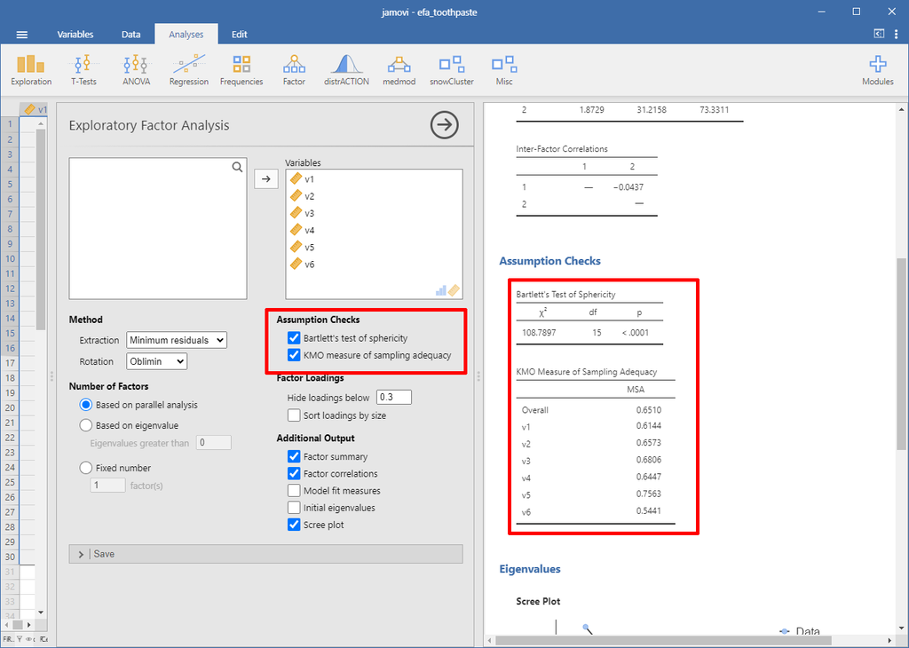

1. Bartlett’s Test of Sphericity

What does it test?

Bartlett’s Test of Sphericity assesses whether your correlation matrix significantly differs from an identity matrix (where variables do not correlate at all). In other words, it checks if there are meaningful correlations among your variables that justify using factor analysis.

Interpretation:

A **significant** result (p < .05) indicates that your variables are sufficiently correlated to justify performing Exploratory Factor Analysis (EFA). Here, the p-value is **< .0001**, clearly indicating significant correlations among variables (v1–v6). This strongly supports proceeding with factor analysis.

2. KMO Measure of Sampling Adequacy

What does it test?

The KMO measure evaluates how suitable your dataset is for factor analysis. Specifically, it measures the adequacy of the sample size and the strength of correlations among variables. KMO provides an **overall** score and individual scores for each variable.

Interpretation:

- **Overall KMO**: 0.6510

The general guidelines for interpreting KMO values are:

- **0.80–1.00**: Excellent
- **0.70–0.79**: Good
- **0.60–0.69**: Mediocre (acceptable)
- **0.50–0.59**: Poor (but still minimally acceptable)
- **Below 0.50**: Unacceptable (requires reconsideration of variables or sample size)

In your output, the overall KMO is **0.651**, considered **mediocre but acceptable**, suggesting that the dataset is suitable for factor analysis, though there is room for improvement (e.g., increasing sample size or refining items).

Individual KMO values (by variables):

- **v1**: 0.6144 (acceptable, mediocre)
- **v2**: 0.6573 (acceptable, mediocre)
- **v3**: 0.6806 (acceptable, mediocre)
- **v4**: 0.6447 (acceptable, mediocre)
- **v5**: 0.7563 (good; strongest variable)
- **v6**: 0.5441 (poor; weakest variable, but still acceptable)

The weakest variable, v6 (0.5441), is relatively low but still acceptable for inclusion. However, if you encounter issues interpreting the factor structure later, this might be the first item to reconsider.

3. Overall implications:
- **Bartlett’s test** (significant):  
  Strongly supports performing factor analysis, confirming that variables sufficiently correlate.
- **Overall KMO** (mediocre):  
  Indicates that factor analysis is viable, though ideally, the sampling adequacy could be improved by:
  - Adding more participants (sample size).
  - Revising or clarifying item wording.
- **Individual KMO scores**:  
  Variable **v5** appears most suitable for factor analysis, while **v6** might require further examination if factor structure interpretation becomes problematic.

Final Summary:

The Assumption Checks suggest your dataset meets essential criteria for performing EFA:

- Bartlett’s test (**p < .0001**) strongly confirms enough intercorrelations exist to proceed.
- KMO measure (**0.6510 overall**) is adequate, but improvements could enhance the quality of future factor analyses.

Overall, your data are sufficiently robust to confidently interpret the resulting factor structure.